# Supplementary Data

The law of large numbers explains stable conspecific pollen deposition

Author

Jakub Štenc et al.

Published

November 25, 2026

# 1 Section S1: Variance Partitioning Model Diagnostics

To transform the data for the Variance Component Analysis, we compared three approaches: Raw Counts, Log transformation (`log1p`), and Square-Root transformation (`sqrt`).

Model Structure: `variable ~ 1 + (1 | year_fac / plant_id)`

## 1.1 S1.1 Heterospecific Pollen (HP)

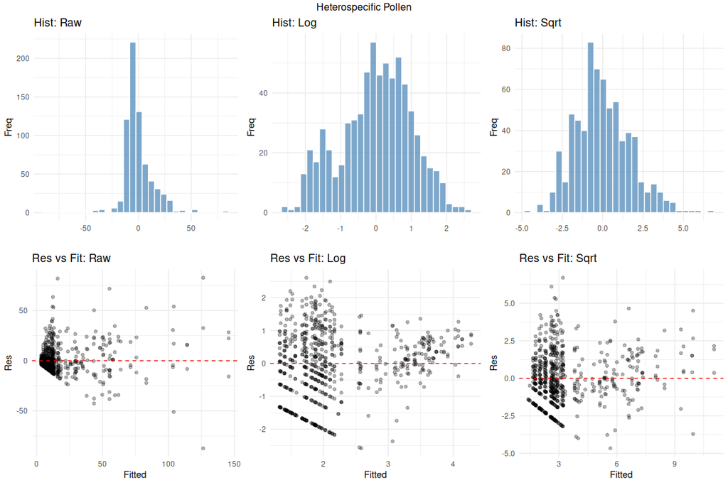

Diagnostics for Heterospecific Pollen (HP).

**Selection**: The raw data (Left) shows severe heteroscedasticity. Both comparisons suggest stabilization, but Square-Root was chosen for alignment with standard count data practices.

## 1.2 S1.2 Conspecific Pollen (CP)

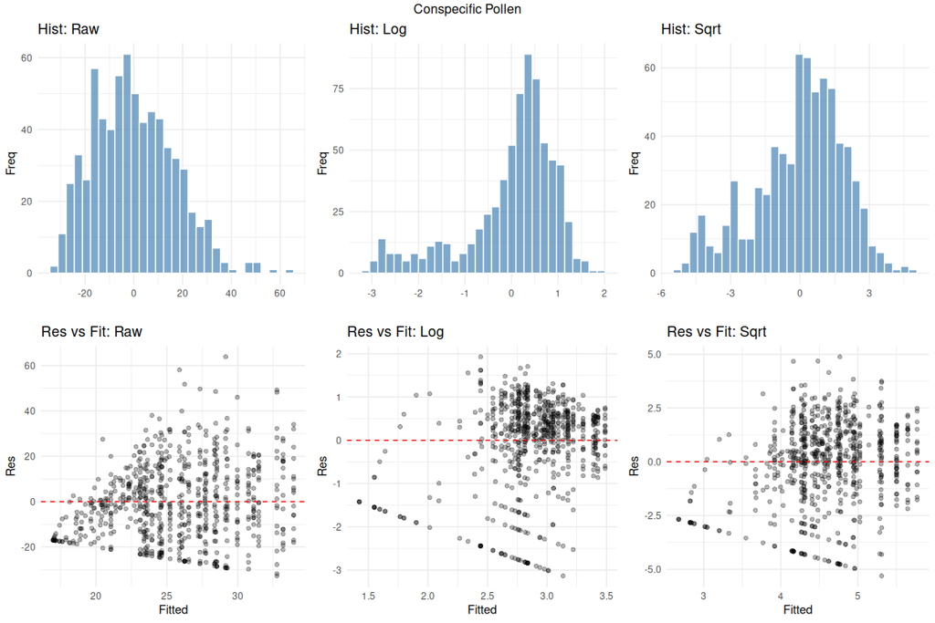

Diagnostics for Conspecific Pollen (CP).

## 1.3 S1.3 Proportion HP (HP / Total)

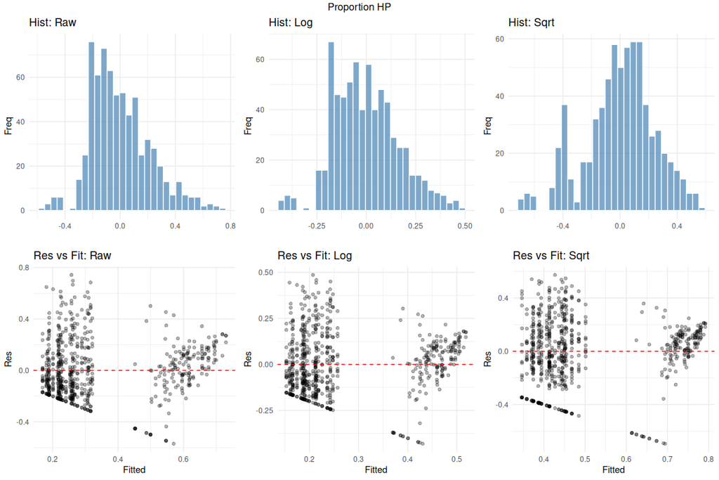

Diagnostics for Proportion HP (HP / (CP+HP)).

**Selection**: Proportions are bounded [0,1]. While Binomial/Beta models are theoretically superior, for the purpose of VCA (partitioning variance), the Square-Root transformation provides a reasonable approximation of normality for the residuals.

# 2 Section S2: Model Selection for CP-HP Relationship

To determine the functional form of the relationship between Conspecific (CP) and Heterospecific (HP) pollen deposition, we compared Linear (Type 1) and Exponential (Type 3) models using Akaike Information Criterion (AIC).

**Data Aggregation**: We aggregated pollen counts to the plant level (mean per plant) to account for multiple stigmas sampled from the same individual.

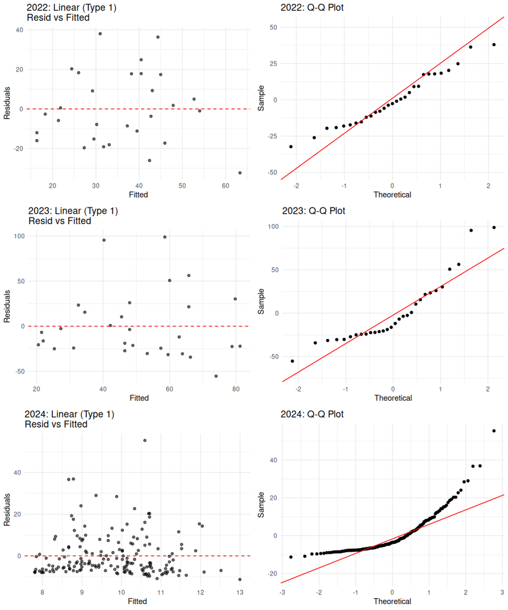

Diagnostic plots for the selected models (Linear or Exponential) for each year. Comparisons based on AIC.

# 3 Section S3: Diagnostic Plots for Slope Comparison Model

To validate the use of the square-root transformation for the interannual slope comparison analysis (aggregated plant-level data), we examined the residual diagnostics of the linear model.

**Model**: `lm(sqrt(mean_HP) ~ sqrt(mean_CP) * Year, data = aggregated_data)`

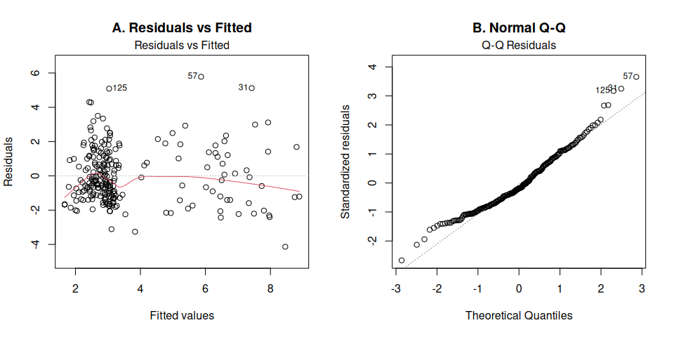

Figure 1: Diagnostic plots for the Square-Root Transformed Model. A) Residuals vs Fitted showing no obvious patterns (homoscedasticity). B) Q-Q Plot showing reasonable normality.

# 4 Section S4: Sampling Summaries

## 4.1 S4.1 Pollen Load Sampled Individuals

The following table provides an overview of all individually sampled pollinators for the pollen load analysis.

**Table S1**: Overview of Pollen Load Sampled Individuals (2024)  
*Number of sampled individuals per pollinator species and collection date.*

| Pollinator Morphogroup | Pollinator Species | Aug 16 | Aug 17 | Aug 18 | Total |
| --- | --- | --- | --- | --- | --- |
| Apis mellifera |  |  |  |  |  |
|  | Apis mellifera | 1 | 0 | 0 | 1 |
| Eristalis spp. |  |  |  |  |  |
|  | Eristalis tenax | 41 | 14 | 22 | 77 |
|  | Eristalis pertinax | 11 | 12 | 24 | 47 |
|  | Eristalis interrupta | 27 | 11 | 8 | 46 |
|  | Eristalis arbustorum | 6 | 5 | 1 | 12 |
|  | Eristalis intricaria | 3 | 4 | 5 | 12 |
|  | Eristalis similis | 2 | 1 | 5 | 8 |
|  | Eristalis sp | 1 | 1 | 0 | 2 |
| Helophilus spp. |  |  |  |  |  |
|  | Helophilus trivittatus | 28 | 12 | 21 | 61 |
|  | Helophilus pendulus | 4 | 1 | 5 | 10 |
|  | Helophilus hybridus | 5 | 0 | 0 | 5 |
| Other |  |  |  |  |  |
|  | Sarcophaga sp | 7 | 4 | 2 | 13 |
|  | Myathropa florea | 3 | 0 | 0 | 3 |
|  | Sericomyia | 1 | 1 | 0 | 2 |
|  | Tachinidae | 1 | 0 | 0 | 1 |

## 4.2 S4.2 Single-Visit Deposition (SVD) Sample Sizes

**Table S2: SVD Sample Sizes**  
*Number of SVD observations recorded per pollinator species and year.*

| morphogroup | Species | 2024 | 2022 | 2023 | Grand Total |
| --- | --- | --- | --- | --- | --- |
| Apis mellifera |  |  |  |  |  |
|  | Apis_mellifera | 5 | 0 | 0 | 5 |
| Bombus spp. |  |  |  |  |  |
|  | Bombus_lapidarius | 0 | 2 | 4 | 6 |
|  | Bombus_sylvarum | 0 | 0 | 2 | 2 |
|  | Bombus_terrestris | 1 | 0 | 0 | 1 |
| Eristalis spp. |  |  |  |  |  |
|  | Eristalis_tenax | 38 | 14 | 3 | 55 |
|  | Eristalis_interrupta | 12 | 0 | 0 | 12 |
|  | Eristalis_arbustorum | 3 | 0 | 2 | 5 |
|  | Eristalis_intricaria | 1 | 1 | 1 | 3 |
|  | Eristalis_pertinax | 1 | 0 | 0 | 1 |
|  | Eristalis_similis | 1 | 0 | 0 | 1 |
| Helophilus spp. |  |  |  |  |  |
|  | Helophilus_trivittatus | 17 | 1 | 0 | 18 |
|  | Helophilus_pendulus | 6 | 0 | 0 | 6 |
|  | Helophilus_sp | 0 | 1 | 0 | 1 |
| Other |  |  |  |  |  |
|  | Sarcophaga_sp | 5 | 0 | 0 | 5 |
|  | Dasysyrphus_sp | 0 | 0 | 2 | 2 |
|  | Sphaerophoria_sp | 0 | 0 | 1 | 1 |

## 4.3 S4.3 Pollinator Community Composition

Table S3 presents the abundance and relative abundance of all pollinator taxa recorded across the three study years. **Note on Abundance**: “Abundance” (Count) represents the raw number of recorded interaction events (unstandardized). Relative abundance (%) is calculated as the species’ count divided by the total number of visits for that year.

**Table S3**: Raw abundance (Count) and relative abundance (%) of all pollinator taxa across study years

| Species | Count 2022 | % 2022 | Count 2023 | % 2023 | Count 2024 | % 2024 |
| --- | --- | --- | --- | --- | --- | --- |
| Eristalis_tenax | 321 | 45.28 | 350 | 50.00 | 456 | 28.70 |
| Eristalis_interrupta | 88 | 12.41 | 49 | 7.00 | 266 | 16.74 |
| Helophilus_trivittatus | 53 | 7.48 | 16 | 2.29 | 277 | 17.43 |
| Eristalis_pertinax | 4 | 0.56 | 7 | 1.00 | 127 | 7.99 |
| Zygaena_sp | 17 | 2.40 | 58 | 8.29 | 54 | 3.40 |
| Helophilus_pendulus | 12 | 1.69 | 20 | 2.86 | 73 | 4.59 |
| Apis_mellifera | 9 | 1.27 | 22 | 3.14 | 67 | 4.22 |
| Bombus_lapidarius | 14 | 1.97 | 51 | 7.29 | 6 | 0.38 |
| Sarcophaga_sp | 4 | 0.56 | 4 | 0.57 | 56 | 3.52 |
| Eristalis_intricaria | 14 | 1.97 | 21 | 3.00 | 19 | 1.20 |
| Sericomyia_silentis | 31 | 4.37 | 10 | 1.43 | 9 | 0.57 |
| Bombus_pascuorum | 23 | 3.24 | 19 | 2.71 | 5 | 0.31 |
| Aglais_io | 0 | 0.00 | 1 | 0.14 | 32 | 2.01 |
| Bombus_terrestris_agg | 6 | 0.85 | 17 | 2.43 | 6 | 0.38 |
| Eristalis_arbustorum | 3 | 0.42 | 4 | 0.57 | 21 | 1.32 |
| Helophilus_hybridus | 26 | 3.67 | 0 | 0.00 | 1 | 0.06 |
| Muscid-like_fly | 19 | 2.68 | 3 | 0.43 | 5 | 0.31 |
| Maniola_jurtina | 13 | 1.83 | 2 | 0.29 | 8 | 0.50 |
| Calliphoridae_other | 0 | 0.00 | 0 | 0.00 | 16 | 1.01 |
| Tachina_sp | 4 | 0.56 | 2 | 0.29 | 9 | 0.57 |
| Noctuidae | 2 | 0.28 | 1 | 0.14 | 9 | 0.57 |
| Geometridae | 0 | 0.00 | 0 | 0.00 | 11 | 0.69 |
| Pieris_rapae | 5 | 0.71 | 0 | 0.00 | 4 | 0.25 |
| Bombus_sylvarum | 2 | 0.28 | 5 | 0.71 | 1 | 0.06 |
| Microlepidoptera | 5 | 0.71 | 0 | 0.00 | 3 | 0.19 |
| Episyrphus_balteatus | 2 | 0.28 | 5 | 0.71 | 0 | 0.00 |
| Helophilus_sp | 5 | 0.71 | 2 | 0.29 | 0 | 0.00 |
| Bombus_soroeensis | 2 | 0.28 | 4 | 0.57 | 0 | 0.00 |
| Conopidae | 2 | 0.28 | 4 | 0.57 | 0 | 0.00 |
| Eristalis_similis | 1 | 0.14 | 0 | 0.00 | 5 | 0.31 |
| Myathropa_florea | 0 | 0.00 | 0 | 0.00 | 6 | 0.38 |
| Tachinidae_sp | 1 | 0.14 | 0 | 0.00 | 4 | 0.25 |
| Pieris_napi | 4 | 0.56 | 0 | 0.00 | 0 | 0.00 |
| Syrphus_sp | 1 | 0.14 | 2 | 0.29 | 1 | 0.06 |
| Cylindromyia_sp | 0 | 0.00 | 2 | 0.29 | 2 | 0.13 |
| Eristalis_sp | 0 | 0.00 | 3 | 0.43 | 1 | 0.06 |
| Argynnis_sp | 0 | 0.00 | 0 | 0.00 | 4 | 0.25 |
| Pieris_brassicae | 2 | 0.28 | 0 | 0.00 | 1 | 0.06 |
| Aglais_urticae | 0 | 0.00 | 1 | 0.14 | 2 | 0.13 |
| Diptera_mmm | 0 | 0.00 | 3 | 0.43 | 0 | 0.00 |
| Araschnia_levana | 0 | 0.00 | 0 | 0.00 | 3 | 0.19 |
| Calyptrata_mm | 1 | 0.14 | 0 | 0.00 | 1 | 0.06 |
| Dasysyrphus_sp | 1 | 0.14 | 0 | 0.00 | 1 | 0.06 |
| Dasysyrphus_tricinctus | 2 | 0.28 | 0 | 0.00 | 0 | 0.00 |
| Eristalis_obscura | 2 | 0.28 | 0 | 0.00 | 0 | 0.00 |
| Cerambycidae_other | 0 | 0.00 | 2 | 0.29 | 0 | 0.00 |
| Sicus_ferrugineus | 0 | 0.00 | 2 | 0.29 | 0 | 0.00 |
| Sphaerophoria_sp | 0 | 0.00 | 1 | 0.14 | 1 | 0.06 |
| Syritta_pipiens | 0 | 0.00 | 2 | 0.29 | 0 | 0.00 |
| Athalia_rosae | 0 | 0.00 | 0 | 0.00 | 2 | 0.13 |
| Halictidae_other | 0 | 0.00 | 0 | 0.00 | 2 | 0.13 |
| Lucilia_sp | 0 | 0.00 | 0 | 0.00 | 2 | 0.13 |
| Stomorhina_lunata | 0 | 0.00 | 0 | 0.00 | 2 | 0.13 |
| Ammophila_sp | 1 | 0.14 | 0 | 0.00 | 0 | 0.00 |
| Boloria_dia | 1 | 0.14 | 0 | 0.00 | 0 | 0.00 |
| Cecidomyidae | 1 | 0.14 | 0 | 0.00 | 0 | 0.00 |
| Eriothrix_sp | 1 | 0.14 | 0 | 0.00 | 0 | 0.00 |
| Hesperiidae | 1 | 0.14 | 0 | 0.00 | 0 | 0.00 |
| Pyraustra_purpuralis | 1 | 0.14 | 0 | 0.00 | 0 | 0.00 |
| Scaeva_selenitica | 1 | 0.14 | 0 | 0.00 | 0 | 0.00 |
| Tipulidae | 1 | 0.14 | 0 | 0.00 | 0 | 0.00 |
| Bombus_sp | 0 | 0.00 | 1 | 0.14 | 0 | 0.00 |
| Diptera | 0 | 0.00 | 1 | 0.14 | 0 | 0.00 |
| Sicus_sp | 0 | 0.00 | 1 | 0.14 | 0 | 0.00 |
| Volucella_pellucens | 0 | 0.00 | 1 | 0.14 | 0 | 0.00 |
| Volucella_sp | 0 | 0.00 | 1 | 0.14 | 0 | 0.00 |
| Autographa_gamma | 0 | 0.00 | 0 | 0.00 | 1 | 0.06 |
| Bělopásek | 0 | 0.00 | 0 | 0.00 | 1 | 0.06 |
| Crambidae | 0 | 0.00 | 0 | 0.00 | 1 | 0.06 |
| Hnědásek | 0 | 0.00 | 0 | 0.00 | 1 | 0.06 |
| Ichneumonidae | 0 | 0.00 | 0 | 0.00 | 1 | 0.06 |
| Phasiini | 0 | 0.00 | 0 | 0.00 | 1 | 0.06 |
| Pieris_sp | 0 | 0.00 | 0 | 0.00 | 1 | 0.06 |
| Polygonia_c-album | 0 | 0.00 | 0 | 0.00 | 1 | 0.06 |

# 5 Section S5: Variance Partitioning Components

The following tables detail the variance components (Inter-Annual and Intra-Annual) for Conspecific (Table S4) and Heterospecific (Table S5) pollen deposition models.

**Table S4**: Variance partitioning of square-root transformed conspecific TPD  
*Results for Global (Inter-Annual) and 2024 (Intra-Annual) analyses.*

| Analysis Scope | Variance Source | Variance Component | SD | % Total |
| --- | --- | --- | --- | --- |
| Inter-Annual | Stigma | 3.93 | 1.98 | 82.1% |
| Inter-Annual | Plant | 0.71 | 0.84 | 14.7% |
| Inter-Annual | Year | 0.15 | 0.39 | 3.2% |
| Intra-Annual (2024 only) | Stigma | 1.74 | 1.32 | 38.2% |
| Intra-Annual (2024 only) | Plant | 2.76 | 1.66 | 60.7% |
| Intra-Annual (2024 only) | Date | 0.05 | 0.22 | 1.1% |

**Table S5**: Variance partitioning of square-root transformed heterospecific TPD  
*Results for Global (Inter-Annual) and 2024 (Intra-Annual) analyses.*

| Analysis Scope | Variance Source | Variance Component | SD | % Total |
| --- | --- | --- | --- | --- |
| Inter-Annual | Stigma | 3.22 | 1.80 | 31.3% |
| Inter-Annual | Plant | 3.56 | 1.89 | 34.6% |
| Inter-Annual | Year | 3.51 | 1.87 | 34.1% |
| Intra-Annual (2024 only) | Stigma | 1.50 | 1.23 | 47.2% |
| Intra-Annual (2024 only) | Plant | 1.66 | 1.29 | 52.1% |
| Intra-Annual (2024 only) | Date | 0.02 | 0.15 | 0.7% |

# 6 Section S6: Significance Testing of Variance Partitioning

To test the statistical significance of the variance components (Year, Date, and Plant) for both Heterospecific (HP) and Conspecific (CP) pollen deposition, we performed Likelihood Ratio Tests (LRT) using the `ranova()` function from the `lmerTest` package.

**Table S6: Significance Testing of Variance Components**  
*Likelihood Ratio Tests for Inter-Annual and Intra-Annual nested models.*

| Model Scope | Pollen Type | Random Effect | Parameters | Log-Likelihood | AIC | LRT Statistic | df | P-value |
| --- | --- | --- | --- | --- | --- | --- | --- | --- |
| Inter-Annual (2022-2024) | Heterospecific | (1\|plant_id:year_fac) | 3 | -1,532.00 | 3,070.00 | 104.73 | 1 | 0.000 |
| Inter-Annual (2022-2024) | Heterospecific | (1\|year_fac) | 3 | -1,495.83 | 2,997.66 | 32.39 | 1 | 0.000 |
| Inter-Annual (2022-2024) | Conspecific | (1\|plant_id:year_fac) | 3 | -1,502.69 | 3,011.38 | 18.43 | 1 | 0.000 |
| Inter-Annual (2022-2024) | Conspecific | (1\|year_fac) | 3 | -1,495.20 | 2,996.40 | 3.44 | 1 | 0.063 |
| Intra-Annual (2024) | Heterospecific | (1\|plant_id:date_fac) | 3 | -1,036.27 | 2,078.53 | 126.53 | 1 | 0.000 |
| Intra-Annual (2024) | Heterospecific | (1\|date_fac) | 3 | -973.10 | 1,952.19 | 0.19 | 1 | 0.663 |
| Intra-Annual (2024) | Conspecific | (1\|plant_id:date_fac) | 3 | -1,129.41 | 2,264.82 | 184.71 | 1 | 0.000 |
| Intra-Annual (2024) | Conspecific | (1\|date_fac) | 3 | -1,037.23 | 2,080.46 | 0.36 | 1 | 0.550 |

# 7 Section S7: Data Distribution

The distribution of heterospecific TPD counts is highly skewed, with many low values and a long tail of high deposition events.

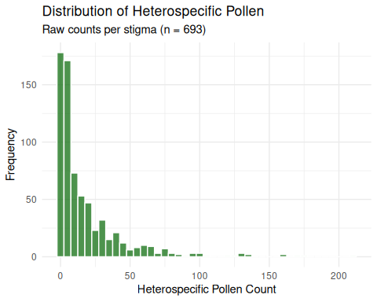

Figure 2: Distribution of Heterospecific Pollen Counts on Stigmas.

# 8 Section S8: Archived Data and Code

All data and the R code needed to reproduce the analyses are archived on Figshare (https://doi.org/10.6084/m9.figshare.35119726; during peer review accessible via https://figshare.com/s/15bd3310c8fbe6d34a36). The archive contains a `README.md` file describing every variable. The data files are:

- `pollen_deposition.csv`: conspecific and heterospecific pollen counts on terminal-stage stigmas of *Succisa pratensis* (2022–2024; 714 stigmas, of which 693 with pollen counts were analysed).
- `SVD_Succisa_pratensis.csv`: single-visit deposition experiments on virgin stigmas (124 visits, 2022–2024).
- `pollen_load_and_guts_2024_Succisa_pratensis.csv`: pollen counts on the bodies (and in the guts) of 300 flower visitors caught on *S. pratensis* in 2024.
- `interaction_data_all_22_24.csv` and `interaction_data_Succisa_22_24.csv`: plant–pollinator interactions recorded in the permanent plots (whole community and *S. pratensis* only).
- `plant_abundance_22_24.csv`: flowering plant abundance per plot and year.
- `plant_species_codes.csv`: plant species abbreviations used in the abundance and interaction data.
- `plot_coordinates.csv`: positions of the permanent plots.